# Can we use FIFA videogame data in soccer analytics?

Alvise Dei Rossi (2004250), Lorenzo Corrado (2020623), Riccardo Vinco (2005800)

A.A. 2020/2021

## Introduction

Football is one of the most important sports in all the world. Events like the World Championship are very popular and have a huge resonance on the media. We are now approaching the European Championship, and it is simple to feel the importance of this event. For our project, we are interested in understanding if the value can be related to the ability of a player. We will analyze a dataset looking for this relationship. With the best model found we will look the most overrated and underrated players indicated by the model. The practical side of this analysis spaces from a basic usage in the rising field of e-sports to real field market considerations. Another application is to use our data to train three statistical models to try to predict the outcomes (and their probabilities) of matches in the lastest Serie A league season.

The whole project is primarely based on a *Kaggle* dataset that contains the statistics about football players in the famous videogame FIFA (https://www.kaggle.com/stefanoleone992/fifa-21-complete-player-dataset). The whole project, is based on 2020/2021 championships data. The choice of the dataset was determined by its cheapness and by the presence of many statistics useful for the videogame but difficult to get in the real world. It is in fact difficult to assign a value from 0 to 100 regarding different abilities like defending, ball control or crossing to all the players in the world. FIFA game is bound in defining these values for the game. Even though they’re fictitious and simulated, we are interested in their possible usefulness in real world applications. The only value strictly related to reality is the value of the players, which the game takes from sites like https://www.transfermarkt.it/uefa-champions-league/marktwerte/pokalwettbewerb/CL at the release. The choice of modelling the value based on the other “simulated” statistics is so a way to see if, in general, we can take the dataset as valid for other analysis. The main project is going to focus on modeling the value, and at the end the two applications will be shown. From the results of the applications we are going to determine if the FIFA dataset has the potential to be used in real applications.

## Initial data: Dataset and exploratory analysis

To perform the analysis, we start from looking at the dataset. This dataset does not require a lot of preprocessing in order to be used. Beforehand, certain variables with uncertain meaning has been removed (i.e. rb, rf, rw, etc.). Some other particular variables were removed, like information about loaning and images. All the records with at least one Not Available entry were also removed. A last modification was to remove the goalkeepers because they do not share some variables with the other players, so they would require a separate analysis. This preprocessing analysis is reported here in an inactive R code chunk.

Let’s start with importing the dataset. We call it *df* and we take strings values as factors. We import it like a data frame and we look for its general structure. The dataset takes into consideration 58 variables. No NA entries are present and all players have a positive value for our variable of interest *value_eur*.

```
## Are there any NAs?  FALSE
```

```
## Number of players with invalid money value:  0
```

For our purposes, we are going to consider only those players who belong to a top tier league. This reduces our entries to the number of 12808. A general idea of which variables are included and what type and values they can take can be seen in this frame.

```
## 'data.frame':    12808 obs. of  58 variables:
##  $ sofifa_id                 : int  158023 20801 188545 190871 192985 231747 203376 208722 209331 153079 ...
##  $ short_name                : Factor w/ 15797 levels "�. Baiaram","�. Bodișteanu",..: 8989 2951 12807 11591 8043 8239 15110 13779 10638 13318 ...
##  $ age                       : int  33 35 31 28 29 21 28 28 28 32 ...
##  $ height_cm                 : int  170 187 184 175 181 178 193 175 175 173 ...
##  $ weight_kg                 : int  72 83 80 68 70 73 92 69 71 70 ...
##  $ nationality               : Factor w/ 161 levels "Afghanistan",..: 7 123 122 21 15 55 107 134 46 7 ...
##  $ club_name                 : Factor w/ 681 levels "1. FC Heidenheim 1846",..: 220 341 222 452 387 452 375 375 375 387 ...
##  $ league_name               : Factor w/ 52 levels "Argentina Primera División",..: 43 26 21 19 17 19 17 17 17 17 ...
##  $ overall                   : int  93 92 91 91 91 90 90 90 90 89 ...
##  $ potential                 : int  93 92 91 91 91 95 91 90 90 89 ...
##  $ value_eur                 : int  67500000 46000000 80000000 90000000 87000000 105500000 75500000 78000000 78000000 53000000 ...
##  $ wage_eur                  : int  560000 220000 240000 270000 370000 160000 210000 250000 250000 300000 ...
##  $ player_positions          : Factor w/ 609 levels "CAM","CAM, CDM",..: 538 586 559 330 11 593 56 329 500 559 ...
##  $ preferred_foot            : Factor w/ 2 levels "Left","Right": 1 2 2 2 2 2 2 2 1 2 ...
```

[output cut: 44 more lines]

There are 8 factor variables and 50 numeric variables. All the numeric variables are *integers* and not *real*, and this is probably given to get a smaller memory needing for storage. Some factors are really big, taking up to 609 levels.

Before starting to visualize our data, let’s just see which players are valued the most and the less in the dataset.

```
##             short_name value_eur    short_name value_eur
## 1             L. Messi  67500000      Ai Zhibo     30000
## 3       R. Lewandowski  80000000       Wu Qing     30000
## 4            Neymar Jr  90000000   I. González     30000
## 5         K. De Bruyne  87000000    J. Machado     25000
## 6            K. Mbappé 105500000    R. Cretaro     30000
## 7          V. van Dijk  75500000    A. Bennett     20000
## 8              S. Mané  78000000 M. McChrystal     20000
## 9             M. Salah  78000000  Huang Xiyang     25000
## 14         R. Sterling  72500000    J. Russell     20000
## 15          J. Kimmich  65000000 Ma Chongchong     30000
## 16             H. Kane  71000000    Pan Ximing     30000
## 17           P. Dybala  71000000      A. Foley     25000
## 22           J. Sancho  69500000     Gao Xiang     25000
## 23 T. Alexander-Arnold  60000000  Wang Jianwen     20000
## 24     Bruno Fernandes  63000000      Song Yue     30000
```

We can see the huge difference between the most valued and the less valued. As said in the intro, we are interested in knowing if this difference is reflected also in the players’ statistics and if the statistics themselves can suggest which players are underrated or overrated.

We now are going to perform a quick general analysis of the whole data frame in order to understand relationships and how to treat our data. We start by visualizing the histograms of the numeric variables.

[figure not shown]

We see different distributions of variables: some variables seem to be approximately normal, while others are concentrated in a small portion of values or are bimodal variables. For some variable of interest, we will look at their distribution later on. Let’s see how variables are correlated with an heatmap:

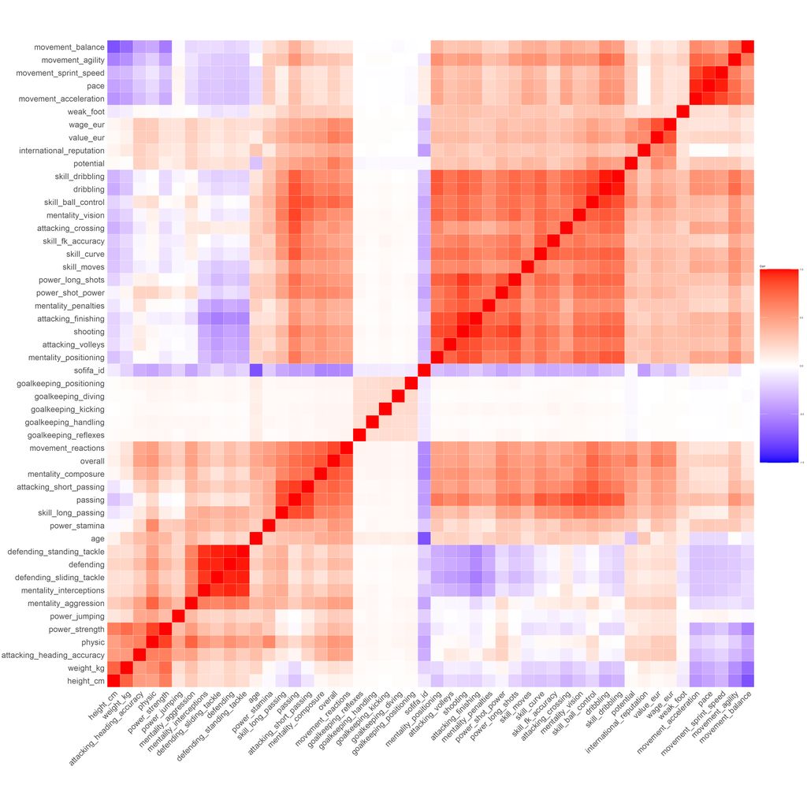

From this brief analysis we have seen that there are some interesting variables and some other we want to get rid of. In our case we are going to exclude the *sofifa_id*, that gives an unique id to a player in the game. We also exclude *short_name*, *nationality*, *club_name* because we are not interested in differences given by the specific teams the players play in or their nationality. *league_rank* was previously set to a unique value so it has been removed aswell. Knowing we have only players who are not goalkeepers, we remove all the statistics related to that role: *goalkeeping_diving*, *goalkeeping_handling*, *goalkeeping_kicking*, *goalkeeping_positioning*, *goalkeeping_reflexes*. We have decided to remove even the *wage_eur* variable, that is the one of the most correlated with the *value_eur* variable. This is done to understand better the relationship between the value and the players’ strengths and characteristics as simulated by the game, rather than taking into account other money-based statistics.

In order to take into account the difference of the leagues around the world, we define a new qualitative variable *imp_leagues* from *league_name* that separates important european teams versus the rest of the world. We in fact know that in some leagues in Europe are concentrated the most important players of the world, so this distinction can be really helpful. We then discard *league_name*.

A last modification is to deal with the qualitative variables *player_positions* and *team_position*. They are very similar and can take a huge amount of different values. To not discard this information completely, we are going to redefine the role of a player based on these and forming a variable *position* with values: attack, middle, defence, sub. The idea is that, for the value variable, it doesn’t matter the precise role (i.e. right defender vs left defender), but only the general position in the football field.

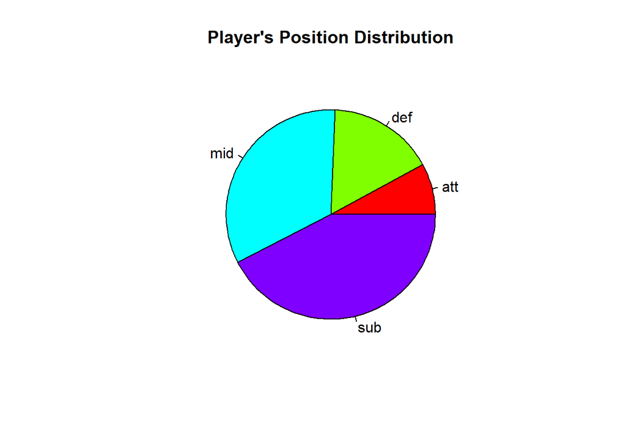

The only qualitative variables not touched are *preferred_foot* (Left vs Right) and *working_rate* which has 9 levels.

As of the remaining variables, we decided to select a few that we thought could be good indications for the value attribution. These variables are: *age*, *potential*, *overall* and *international_reputation*. We will analyze these explicative variables better, as well as train an intuitive model to be compared to the final one. But first we are going to take a closer look at our interest variable: *value_eur*.

##### *Value:*

Value reports the amount of euros needed to buy a certain player. In our case, we have decided to consider it with its usual value, but even with a logarithm (base 10) transformation. The transformation can help us achieve a better model, even if it does not provide us a perfectly normally distributed variable. By the first models we will decide which version to keep.

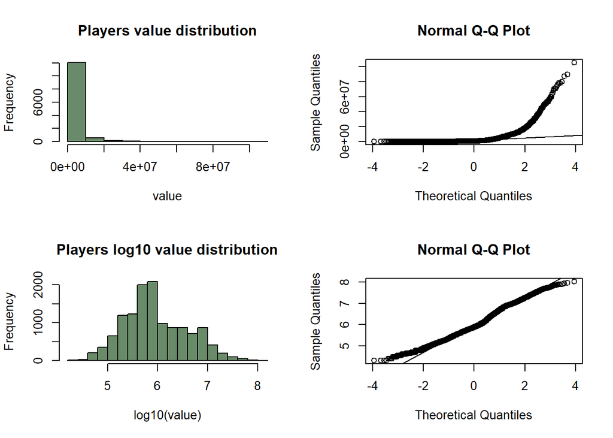

##### *Potential:*

Is the value that tells about the possibility of growth proved by the player. It is a way of taking into account the possible increase of the ability of a certain player. From the plots we can see the distribution and the effect on the value variable:

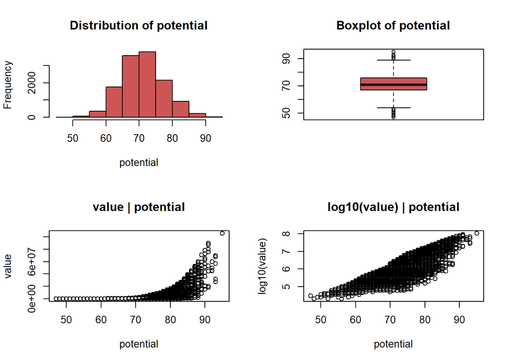

##### *Overall:*

It is a general value that should represent the *overall* ability of the player. It should resume all the others variables. The distribution and relation with the value are shown below.

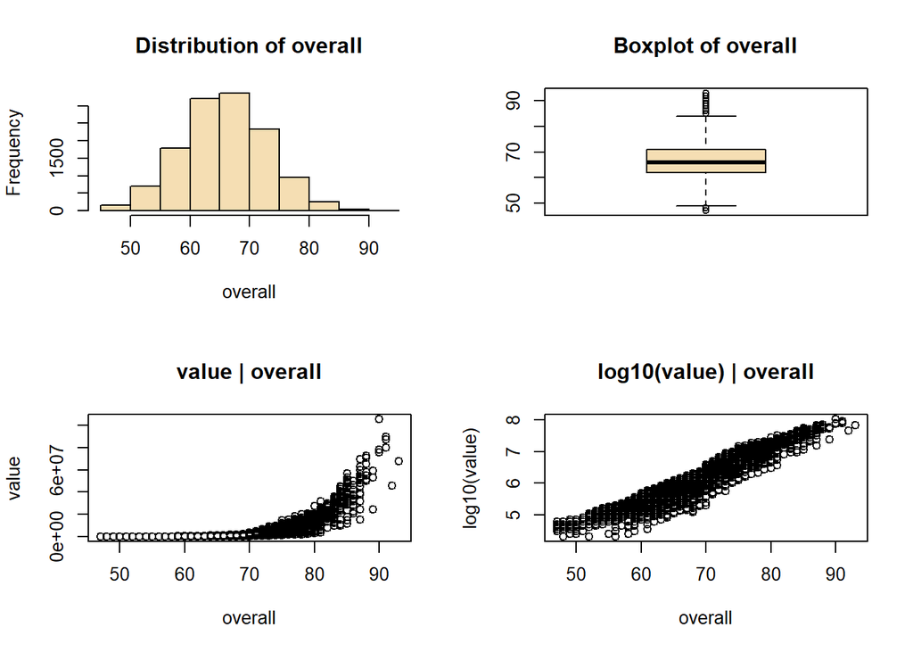

From this variable we have decided to define a new one called *category*. This is a categorical variable meant to distinguish various categories of overall ability and can be useful to group players with a similar total ability.

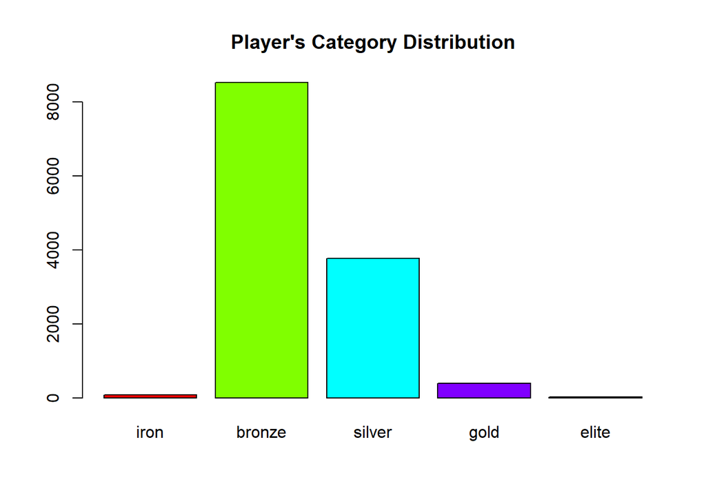

##### *International Reputation:*

It is a discrete ordered value between 1 and 5 that is meant to show how famous and known a certain player is. We expect it to be positively correlated with the value:

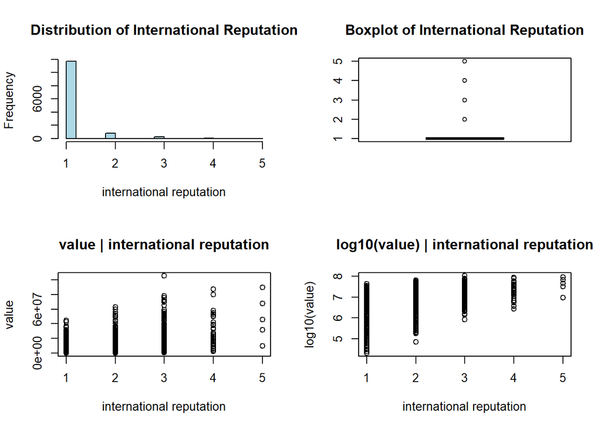

##### *Age:*

It is a discrete value that tells how old is a certain player. We expect the value to increase until the player reaches the prime of his career (usually about 27-28 years old), and then it should start decreasing.

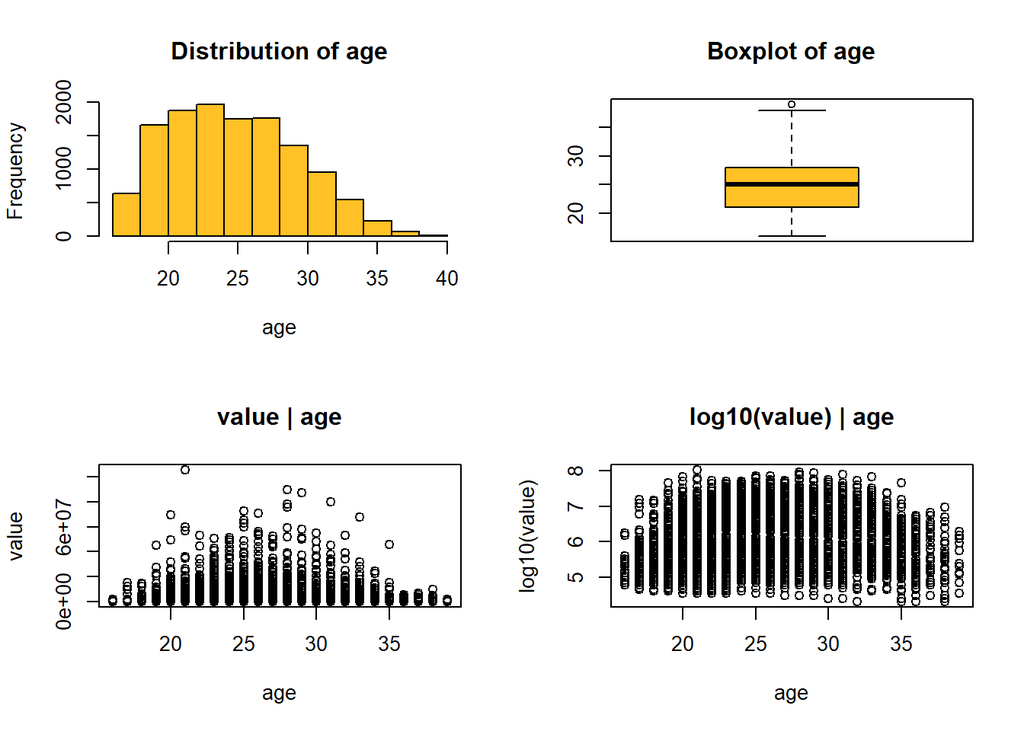

In order to represent in a better and simpler way the relation we described between value and age, we decided to redefine *age* in terms of career phase. We now create a new variable *phase* that divides the ages in 5 categories of career phase: “young”, “prime”, “old”, “near_retirement”, “last_year”.

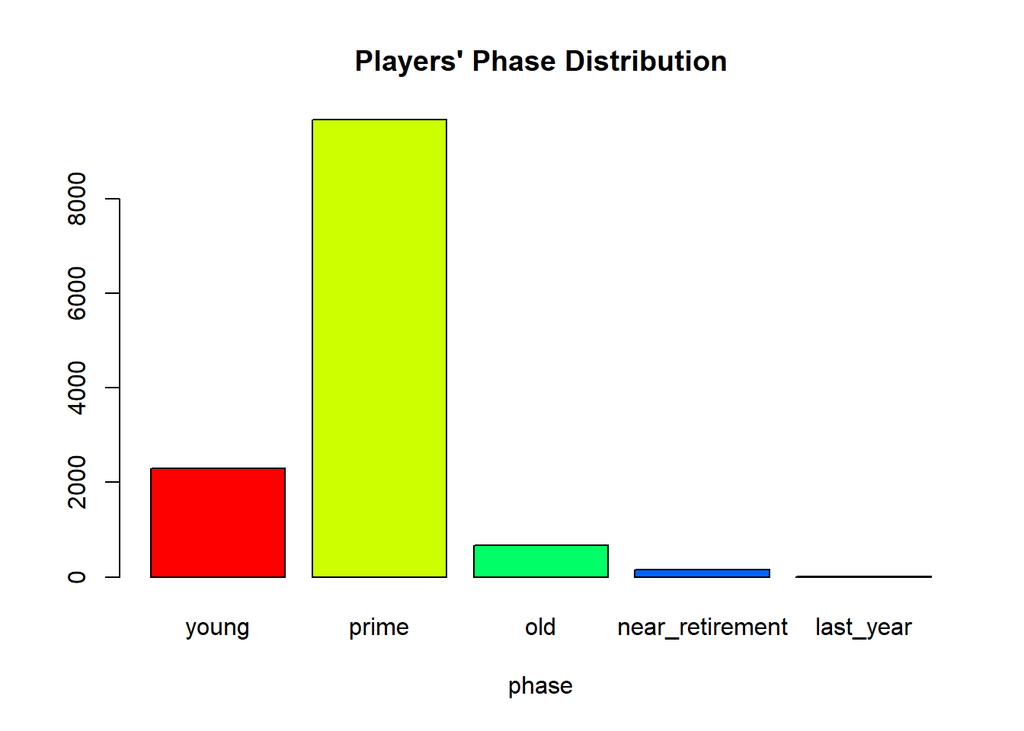

From these variables plots, it can be seen that the logarithmic transformation of the value variable provides a better linear relationship with all the others. It is a first sign on the direction of choosing the transformed version of the variable.

```
## [1] "Variable = 'position':"
```

```
## Analysis of Variance Table
##
## Response: value_eur
##              Df     Sum Sq    Mean Sq F value    Pr(>F)
## position      3 1.1819e+16 3.9397e+15  121.18 < 2.2e-16 ***
## Residuals 12804 4.1627e+17 3.2511e+13
## ---
## Signif. codes:  0 '***' 0.001 '**' 0.01 '*' 0.05 '.' 0.1 ' ' 1
```

```
##   Tukey multiple comparisons of means
##     95% family-wise confidence level
##
## Fit: aov(formula = mod)
##
## $position
##               diff        lwr        upr     p adj
## def-att -2443116.4 -3002700.3 -1883532.4 0.0000000
## mid-att -3011033.3 -3522229.7 -2499836.9 0.0000000
## sub-att -3615212.9 -4115492.2 -3114933.5 0.0000000
## mid-def  -567916.9  -958800.6  -177033.3 0.0010896
## sub-def -1172096.5 -1548590.4  -795602.6 0.0000000
## sub-mid  -604179.6  -904071.6  -304287.5 0.0000014
```

```
## [1] "Variable = 'preferred_foot':"
```

```
## Analysis of Variance Table
##
## Response: value_eur
##                   Df     Sum Sq    Mean Sq F value  Pr(>F)
## preferred_foot     1 1.5900e+14 1.5900e+14  4.7582 0.02918 *
## Residuals      12806 4.2793e+17 3.3417e+13
## ---
## Signif. codes:  0 '***' 0.001 '**' 0.01 '*' 0.05 '.' 0.1 ' ' 1
```

```
## [1] "Variable = 'imp_league':"
```

```
## Analysis of Variance Table
##
## Response: value_eur
##               Df     Sum Sq    Mean Sq F value    Pr(>F)
## imp_league     1 6.6727e+16 6.6727e+16  2364.6 < 2.2e-16 ***
## Residuals  12806 3.6137e+17 2.8218e+13
## ---
## Signif. codes:  0 '***' 0.001 '**' 0.01 '*' 0.05 '.' 0.1 ' ' 1
```

```
## [1] "Variable = 'work_rate':"
```

```
## Analysis of Variance Table
##
## Response: value_eur
##              Df     Sum Sq    Mean Sq F value    Pr(>F)
## work_rate     8 1.9069e+16 2.3837e+15  74.589 < 2.2e-16 ***
## Residuals 12799 4.0902e+17 3.1957e+13
## ---
## Signif. codes:  0 '***' 0.001 '**' 0.01 '*' 0.05 '.' 0.1 ' ' 1
```

```
##   Tukey multiple comparisons of means
##     95% family-wise confidence level
##
## Fit: aov(formula = mod)
##
## $work_rate
##                                  diff        lwr          upr     p adj
## High/Low-High/High        -2966504.30 -3886658.5 -2046350.117 0.0000000
## High/Medium-High/High     -2068226.09 -2774676.1 -1361776.028 0.0000000
## Low/High-High/High        -4127379.04 -5238890.4 -3015867.660 0.0000000
## Low/Low-High/High         -5366207.50 -8174223.1 -2558191.896 0.0000001
## Low/Medium-High/High      -4793695.05 -5883934.3 -3703455.763 0.0000000
## Medium/High-High/High     -2715227.93 -3493402.7 -1937053.128 0.0000000
## Medium/Low-High/High      -3902127.75 -4800206.0 -3004049.469 0.0000000
## Medium/Medium-High/High   -4156291.08 -4817090.7 -3495491.429 0.0000000
## High/Medium-High/Low        898278.21   137506.8  1659049.630 0.0077001
## Low/High-High/Low         -1160874.75 -2307678.6   -14070.917 0.0446061
## Low/Low-High/Low          -2399703.20 -5221874.9   422468.496 0.1710314
## Low/Medium-High/Low       -1827190.75 -2953389.3  -700992.205 0.0000173
## Medium/High-High/Low        251276.37  -576526.4  1079079.176 0.9905555
## Medium/Low-High/Low        -935623.46 -1877029.9     5782.977 0.0529019
## Medium/Medium-High/Low    -1189786.79 -1908367.1  -471206.484 0.0000101
## Low/High-High/Medium      -2059152.95 -3042792.6 -1075513.288 0.0000000
## Low/Low-High/Medium       -3297981.41 -6057880.2  -538082.669 0.0065373
## Low/Medium-High/Medium    -2725468.96 -3685005.9 -1765932.020 0.0000000
## Medium/High-High/Medium    -647001.84 -1228074.5   -65929.159 0.0161842
## Medium/Low-High/Medium    -1833901.67 -2567818.6 -1099984.746 0.0000000
## Medium/Medium-High/Medium -2088065.00 -2498851.6 -1677278.403 0.0000000
## Low/Low-Low/High          -1238828.46 -4129058.0  1651401.107 0.9226394
## Low/Medium-Low/High        -666316.01 -1953598.8   620966.793 0.8020196
## Medium/High-Low/High       1412151.11   375796.3  2448505.940 0.0008004
## Medium/Low-Low/High         225251.29  -903916.5  1354419.084 0.9995128
## Medium/Medium-Low/High      -28912.04  -980296.0   922471.945 1.0000000
## Low/Medium-Low/Low          572512.45 -2309603.3  3454628.181 0.9995278
## Medium/High-Low/Low        2650979.57  -128143.6  5430102.707 0.0754429
## Medium/Low-Low/Low         1464079.75 -1350971.6  4279131.076 0.7977545
## Medium/Medium-Low/Low      1209916.42 -1538651.5  3958484.328 0.9107123
## Medium/High-Low/Medium     2078467.12  1064960.6  3091973.645 0.0000000
## Medium/Low-Low/Medium       891567.30  -216667.4  1999801.955 0.2339110
## Medium/Medium-Low/Medium    637403.96  -289038.5  1563846.429 0.4496127
## Medium/Low-Medium/High    -1186899.83 -1990092.4  -383707.211 0.0001592
## Medium/Medium-Medium/High -1441063.16 -1965686.8  -916439.523 0.0000000
## Medium/Medium-Medium/Low   -254163.33  -944249.2   435922.564 0.9676962
```

```
## [1] "Variable = 'phase':"
```

```
## Analysis of Variance Table
##
## Response: value_eur
##              Df     Sum Sq    Mean Sq F value    Pr(>F)
## phase         4 8.9273e+15 2.2318e+15  68.169 < 2.2e-16 ***
## Residuals 12803 4.1917e+17 3.2740e+13
## ---
## Signif. codes:  0 '***' 0.001 '**' 0.01 '*' 0.05 '.' 0.1 ' ' 1
```

```
##   Tukey multiple comparisons of means
##     95% family-wise confidence level
##
## Fit: aov(formula = mod)
##
## $phase
##                                 diff        lwr        upr     p adj
## prime-young                2088359.9  1726017.6  2450702.3 0.0000000
## old-young                  1056956.7   373518.5  1740394.9 0.0002391
## near_retirement-young      -183927.8 -1471626.3  1103770.6 0.9951308
## last_year-young            -513893.3 -5031912.4  4004125.8 0.9979910
## old-prime                 -1031403.2 -1652861.2  -409945.3 0.0000590
## near_retirement-prime     -2272287.7 -3528189.6 -1016385.9 0.0000080
## last_year-prime           -2602253.2 -7111312.9  1906806.4 0.5138791
## near_retirement-old       -1240884.5 -2624027.8   142258.8 0.1029904
## last_year-old             -1570850.0 -6116992.8  2975292.8 0.8802096
## last_year-near_retirement  -329965.5 -5005272.3  4345341.3 0.9996939
```

```
## [1] "Variable = 'category':"
```

```
## Analysis of Variance Table
##
## Response: value_eur
##              Df     Sum Sq    Mean Sq F value    Pr(>F)
## category      4 3.2156e+17 8.0391e+16  9661.6 < 2.2e-16 ***
## Residuals 12803 1.0653e+17 8.3206e+12
## ---
## Signif. codes:  0 '***' 0.001 '**' 0.01 '*' 0.05 '.' 0.1 ' ' 1
```

```
##   Tukey multiple comparisons of means
##     95% family-wise confidence level
##
## Fit: aov(formula = mod)
##
## $category
##                     diff        lwr      upr     p adj
## bronze-iron     497733.2  -355126.3  1350593 0.5024108
## silver-iron    5139152.4  4280934.6  5997370 0.0000000
## gold-iron     23491455.5 22555868.7 24427042 0.0000000
## elite-iron    66189199.9 64273700.8 68104699 0.0000000
## silver-bronze  4641419.2  4487518.4  4795320 0.0000000
## gold-bronze   22993722.3 22590646.2 23396798 0.0000000
## elite-bronze  65691466.7 63972081.8 67410851 0.0000000
## gold-silver   18352303.1 17938010.0 18766596 0.0000000
## elite-silver  61050047.5 59327998.5 62772096 0.0000000
## elite-gold    42697744.4 40935859.7 44459629 0.0000000
```

## First models

In this section we are going to try out four models, in order to select the most interesting from which to start doing a model selection. Each model will be followed by four plots about the residuals and a plot showing the predictions versus the real value. In the last plot, the closer the points to the bisector, the better the estimate. We start with the general sense model created using the four intuitive variables shown in the previous section.

##### General Sense Model

```
##
## Call:
## lm(formula = value_eur ~ overall + potential + age + international_reputation,
##     data = x)
##
## Residuals:
##       Min        1Q    Median        3Q       Max
## -17930402  -1584297   -385831   1136726  78969541
##
## Coefficients:
##                           Estimate Std. Error t value Pr(>|t|)
## (Intercept)              -24372090     581008  -41.95  < 2e-16 ***
## overall                     547111      11605   47.15  < 2e-16 ***
## potential                   -63342      12371   -5.12  3.1e-07 ***
## age                        -431914      14454  -29.88  < 2e-16 ***
## international_reputation   5583406      94069   59.35  < 2e-16 ***
## ---
## Signif. codes:  0 '***' 0.001 '**' 0.01 '*' 0.05 '.' 0.1 ' ' 1
##
## Residual standard error: 3664000 on 12803 degrees of freedom
## Multiple R-squared:  0.5985, Adjusted R-squared:  0.5984
## F-statistic:  4772 on 4 and 12803 DF,  p-value: < 2.2e-16
```

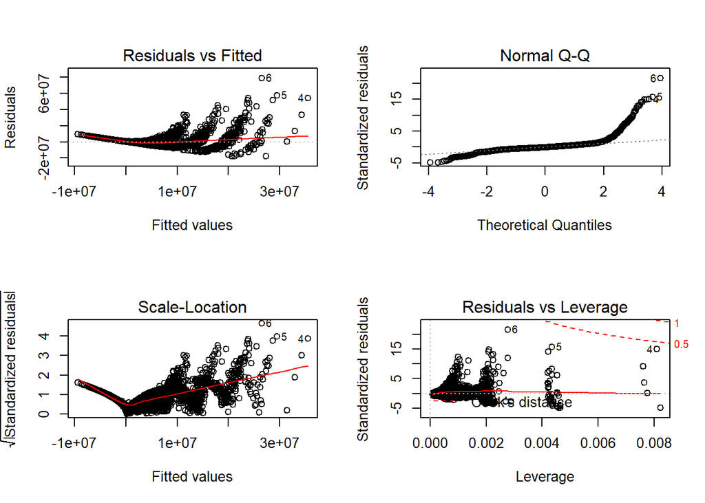

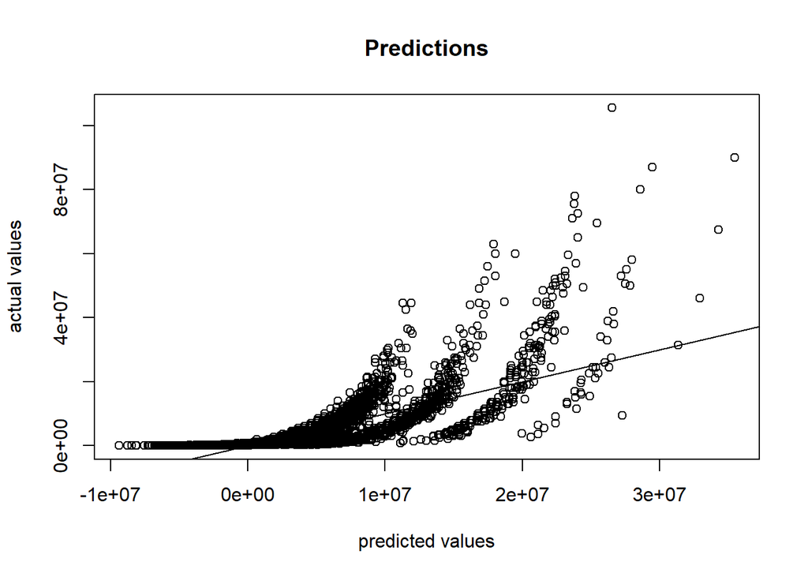

We now analyze the second model. This time the value is in logarithmic scale (10) and so we are fitting a log-linear model. The logarithmic transformation helps us getting a variable that is better distributed while maintaining a right ratio between values by its monotonic property. The explanatory variables are the same as before. All the variables are highly significant, but *international_reputation* which is only significant. The Adjusted R-squared value has increased to 0.9768. Even if the R-squared seems really good, some particulars about residuals are not convincing. In fact, even though residuals now look better distributed and appear to be more compact, their distribution appears to be not normal even in this case. In particular, the distribution has heavy tails with respect to a normal distribution. We’re most likely missing something to properly explain the relationship between the value of players and their attributes. The plot of the predictions has now more values on the bisect, but shows that, after a while, the model fits greater values than the real ones.

```
##
## Call:
## lm(formula = log10(value_eur) ~ overall + potential + age + international_reputation,
##     data = x)
##
## Residuals:
##      Min       1Q   Median       3Q      Max
## -0.53253 -0.05766  0.00198  0.06139  0.44577
##
## Coefficients:
##                            Estimate Std. Error t value Pr(>|t|)
## (Intercept)               0.6139812  0.0150452  40.809  < 2e-16 ***
## overall                   0.0921600  0.0003005 306.684  < 2e-16 ***
## potential                 0.0018321  0.0003203   5.719  1.1e-08 ***
## age                      -0.0359856  0.0003743 -96.143  < 2e-16 ***
## international_reputation  0.0073346  0.0024359   3.011  0.00261 **
## ---
## Signif. codes:  0 '***' 0.001 '**' 0.01 '*' 0.05 '.' 0.1 ' ' 1
##
## Residual standard error: 0.09487 on 12803 degrees of freedom
## Multiple R-squared:  0.9768, Adjusted R-squared:  0.9768
## F-statistic: 1.346e+05 on 4 and 12803 DF,  p-value: < 2.2e-16
```

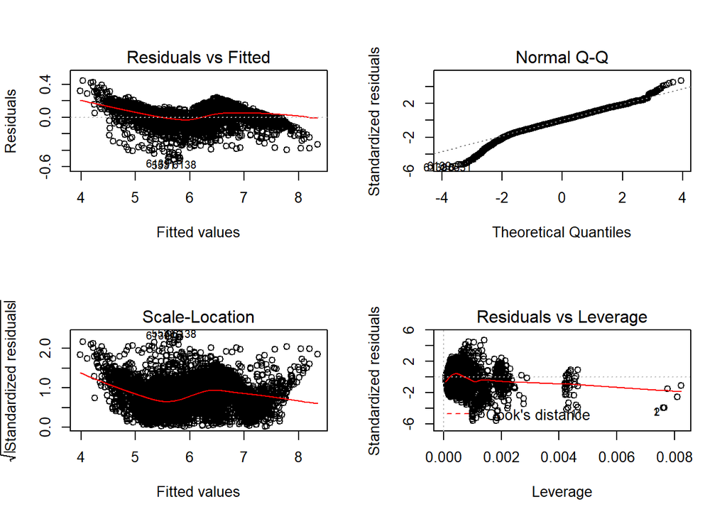

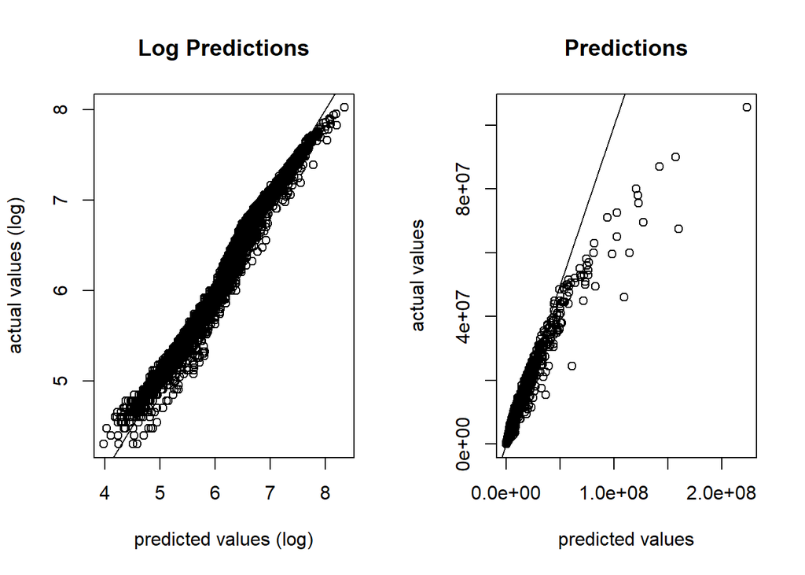

Both these two models have some problems, but, in a certain way, behave really well considering that they came from a subjective small selection of variables following our intuitions. The log-linear model is more convincing, and so we have decided, from now on, to use only the log transformation for the value variable. This seems the most promising way to proceed, becasue of the increase of the fit from 0.59 to 0.97 and a better residual distribution overall.

##### Complete Model

The next model takes into consideration all the variables left in the dataset. It is the simpler choice from which to start understanding which variables are the best to fit the model. On the other hand, even if overfitting, it is a general way to see up to what point the variables we have can explain the *value_eur* one. As said before, we now perform only log-linear models. The complete model contains several variables which figure as not significative, 16 variables highly significant and several others with smaller significance. The model itself is highly significant and the Adjusted R-squared measure reaches a value of 0.9937. The fit seems really good, and the residuals reach their best. Normality assumption seems not to be achievable, but a low amount of high tails lead us to the suspicion that not all the values are in line with the ability of the players. There seems to be one point that behaves as an outlier and there is another which creates high leverage. These two points seems to not have such a bad influence on the others. The values in the prediction plot are now centered and mostly randomly distributed and this is a good sign. Before proceeding in selecting the variables to keep, we are going to consider another model.

```
##
## Call:
## lm(formula = value_eur ~ ., data = x)
##
## Residuals:
##       Min        1Q    Median        3Q       Max
## -0.274912 -0.029681  0.001785  0.031050  0.204473
##
## Coefficients:
##                              Estimate Std. Error t value Pr(>|t|)
## (Intercept)                 7.411e-01  2.559e-02  28.956  < 2e-16 ***
## age                        -1.671e-02  2.680e-04 -62.370  < 2e-16 ***
## height_cm                   1.937e-04  1.296e-04   1.495 0.135049
## weight_kg                   2.059e-04  1.175e-04   1.753 0.079634 .
## overall                     7.125e-02  2.847e-04 250.311  < 2e-16 ***
## potential                   1.198e-02  2.056e-04  58.279  < 2e-16 ***
## preferred_footRight         3.614e-03  1.052e-03   3.436 0.000592 ***
## international_reputation    1.548e-02  1.531e-03  10.108  < 2e-16 ***
## work_rateHigh/Low          -2.435e-03  2.735e-03  -0.890 0.373427
## work_rateHigh/Medium       -4.201e-03  2.043e-03  -2.056 0.039779 *
## work_rateLow/High          -9.573e-03  3.341e-03  -2.865 0.004174 **
## work_rateLow/Low            8.412e-03  8.107e-03   1.038 0.299473
## work_rateLow/Medium        -5.139e-03  3.286e-03  -1.564 0.117833
## work_rateMedium/High       -3.637e-03  2.301e-03  -1.580 0.114026
## work_rateMedium/Low        -3.467e-03  2.698e-03  -1.285 0.198734
## work_rateMedium/Medium     -3.645e-03  1.982e-03  -1.839 0.065887 .
## pace                       -2.288e-03  1.485e-03  -1.541 0.123300
## shooting                    2.818e-03  1.284e-03   2.195 0.028147 *
## passing                    -4.975e-04  1.394e-03  -0.357 0.721104
## dribbling                  -3.076e-03  1.281e-03  -2.400 0.016388 *
## defending                  -6.826e-04  2.135e-04  -3.198 0.001388 **
## physic                      2.219e-04  1.489e-03   0.149 0.881505
## attacking_crossing         -3.686e-04  2.852e-04  -1.292 0.196221
## attacking_finishing        -6.485e-04  5.807e-04  -1.117 0.264127
## attacking_heading_accuracy  9.852e-06  6.695e-05   0.147 0.883021
## attacking_short_passing     6.460e-04  5.024e-04   1.286 0.198506
## attacking_volleys          -1.137e-04  9.105e-05  -1.248 0.211879
## skill_dribbling             1.512e-03  6.465e-04   2.339 0.019353 *
## skill_curve                -1.695e-05  9.371e-05  -0.181 0.856462
## skill_fk_accuracy           1.699e-04  8.734e-05   1.946 0.051733 .
```

[output cut: 23 more lines]

```
## positionsub                -6.059e-03  1.868e-03  -3.243 0.001185 **
## categorybronze             -1.261e-01  5.698e-03 -22.138  < 2e-16 ***
## categorysilver              6.409e-02  6.141e-03  10.438  < 2e-16 ***
## categorygold                2.922e-02  7.189e-03   4.064 4.86e-05 ***
## categoryelite              -1.039e-01  1.336e-02  -7.778 7.94e-15 ***
## phaseprime                  2.601e-02  1.680e-03  15.484  < 2e-16 ***
## phaseold                   -1.880e-01  3.157e-03 -59.551  < 2e-16 ***
## phasenear_retirement       -3.889e-01  5.016e-03 -77.544  < 2e-16 ***
## phaselast_year             -4.807e-01  1.475e-02 -32.589  < 2e-16 ***
## ---
## Signif. codes:  0 '***' 0.001 '**' 0.01 '*' 0.05 '.' 0.1 ' ' 1
##
## Residual standard error: 0.04934 on 12746 degrees of freedom
## Multiple R-squared:  0.9937, Adjusted R-squared:  0.9937
## F-statistic: 3.319e+04 on 61 and 12746 DF,  p-value: < 2.2e-16
```

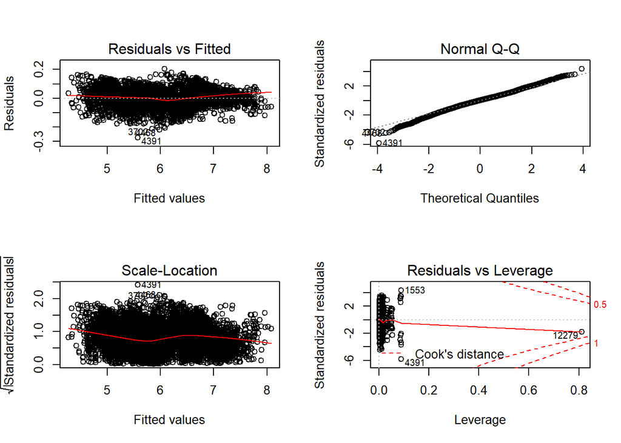

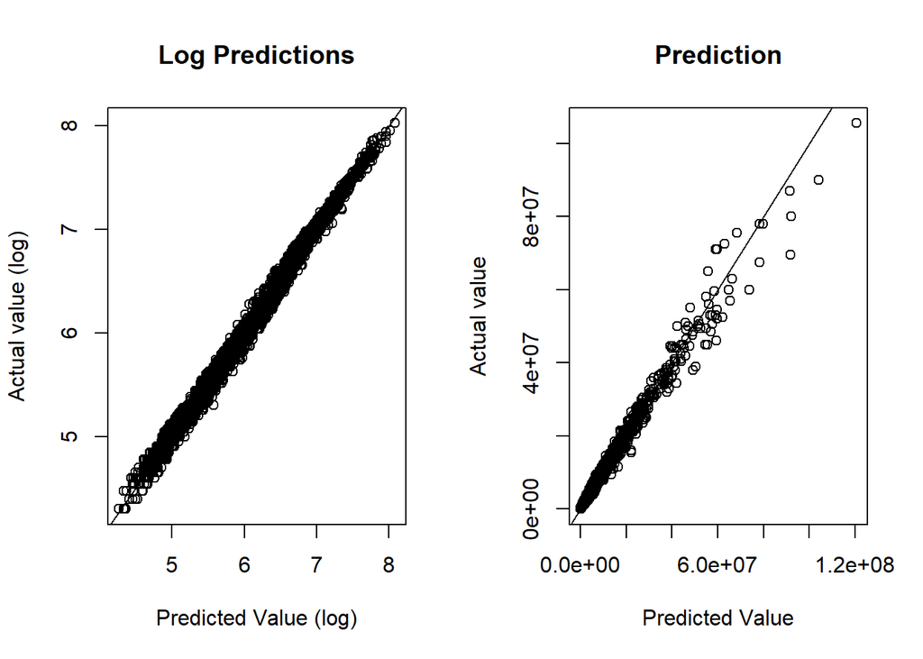

##### Model with interactions

The last model we decided to try is a more general version of the complete one. In particular, to include some interaction while keeping the model small enough to see all the terms in the summary, we added them only between the initial intuitive variables. We saw they were really good to fit a model themselves, and so we took them as most representative. The model obtained is very similar, almost identical, to the complete one. The important fact is that the interaction terms seems to be significant. The fit even increased a little, reaching an Adjusted R-squared value of 0.9944.

```
##
## Call:
## lm(formula = value_eur ~ . + age:overall + age:potential + age:international_reputation +
##     potential:international_reputation + potential:overall +
##     overall:international_reputation, data = x)
##
## Residuals:
##       Min        1Q    Median        3Q       Max
## -0.276763 -0.028992  0.001501  0.029905  0.203408
##
## Coefficients:
##                                      Estimate Std. Error t value Pr(>|t|)
## (Intercept)                         2.141e+00  6.761e-02  31.671  < 2e-16 ***
## age                                -3.326e-02  1.375e-03 -24.196  < 2e-16 ***
## height_cm                           1.504e-04  1.224e-04   1.229 0.219080
## weight_kg                           2.089e-04  1.109e-04   1.884 0.059588 .
## overall                             6.201e-02  1.676e-03  37.002  < 2e-16 ***
## potential                          -2.304e-02  1.363e-03 -16.908  < 2e-16 ***
## preferred_footRight                 2.581e-03  9.933e-04   2.598 0.009380 **
## international_reputation            3.882e-01  2.535e-02  15.312  < 2e-16 ***
## work_rateHigh/Low                  -1.446e-03  2.584e-03  -0.560 0.575709
## work_rateHigh/Medium               -3.400e-03  1.930e-03  -1.761 0.078212 .
## work_rateLow/High                  -7.199e-03  3.157e-03  -2.281 0.022586 *
## work_rateLow/Low                    2.648e-03  7.665e-03   0.345 0.729762
## work_rateLow/Medium                -4.504e-03  3.104e-03  -1.451 0.146881
## work_rateMedium/High               -2.866e-03  2.173e-03  -1.319 0.187238
## work_rateMedium/Low                -1.918e-03  2.549e-03  -0.752 0.451958
## work_rateMedium/Medium             -2.050e-03  1.873e-03  -1.095 0.273688
## pace                               -1.198e-03  1.402e-03  -0.854 0.392937
## shooting                            3.115e-03  1.212e-03   2.571 0.010149 *
## passing                            -3.724e-04  1.316e-03  -0.283 0.777184
## dribbling                          -3.497e-03  1.210e-03  -2.891 0.003853 **
## defending                          -9.074e-04  2.017e-04  -4.498 6.93e-06 ***
## physic                              3.398e-04  1.406e-03   0.242 0.809076
## attacking_crossing                 -2.792e-04  2.693e-04  -1.037 0.299860
## attacking_finishing                -8.153e-04  5.482e-04  -1.487 0.136986
## attacking_heading_accuracy          1.832e-05  6.325e-05   0.290 0.772133
## attacking_short_passing             5.627e-04  4.745e-04   1.186 0.235667
## attacking_volleys                  -7.273e-05  8.596e-05  -0.846 0.397527
## skill_dribbling                     1.683e-03  6.103e-04   2.758 0.005833 **
```

[output cut: 31 more lines]

```
## phaseold                           -2.287e-01  3.391e-03 -67.449  < 2e-16 ***
## phasenear_retirement               -4.331e-01  5.228e-03 -82.846  < 2e-16 ***
## phaselast_year                     -5.358e-01  1.418e-02 -37.774  < 2e-16 ***
## age:overall                        -7.382e-04  4.298e-05 -17.175  < 2e-16 ***
## age:potential                       1.086e-03  4.232e-05  25.653  < 2e-16 ***
## age:international_reputation       -3.805e-03  4.396e-04  -8.655  < 2e-16 ***
## potential:international_reputation -5.252e-03  9.764e-04  -5.379 7.64e-08 ***
## overall:potential                   2.969e-04  1.199e-05  24.772  < 2e-16 ***
## overall:international_reputation    1.785e-03  1.008e-03   1.770 0.076759 .
## ---
## Signif. codes:  0 '***' 0.001 '**' 0.01 '*' 0.05 '.' 0.1 ' ' 1
##
## Residual standard error: 0.04658 on 12740 degrees of freedom
## Multiple R-squared:  0.9944, Adjusted R-squared:  0.9944
## F-statistic: 3.394e+04 on 67 and 12740 DF,  p-value: < 2.2e-16
```

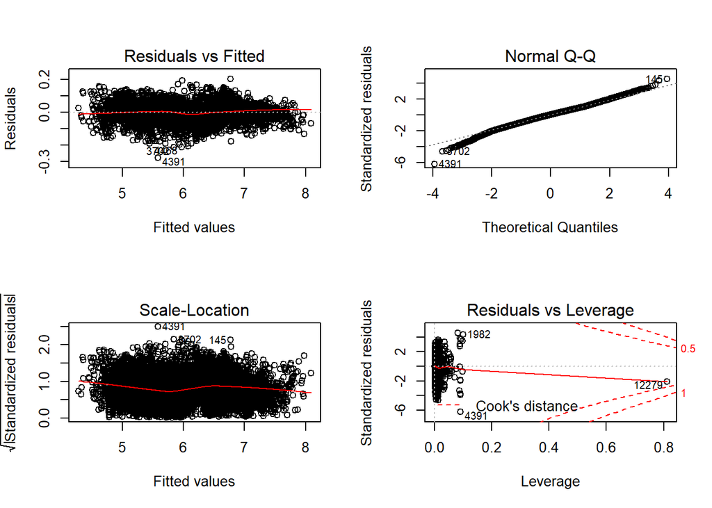

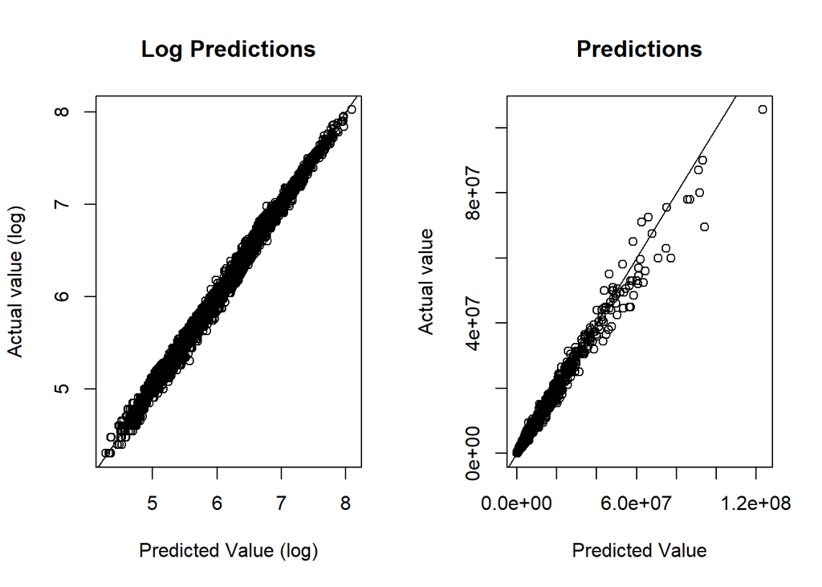

Furthermore, in order to see if the interaction terms are useful or not, an ANOVA test between the complete model and the interaction one is now performed. From the test, it seems that the small change is significant and so we can take the interaction model as the one from which to start selecting the final one.

```
## Analysis of Variance Table
##
## Model 1: value_eur ~ age + height_cm + weight_kg + overall + potential +
##     preferred_foot + international_reputation + work_rate + pace +
##     shooting + passing + dribbling + defending + physic + attacking_crossing +
##     attacking_finishing + attacking_heading_accuracy + attacking_short_passing +
##     attacking_volleys + skill_dribbling + skill_curve + skill_fk_accuracy +
##     skill_long_passing + skill_ball_control + movement_acceleration +
##     movement_sprint_speed + movement_agility + movement_reactions +
##     movement_balance + power_shot_power + power_jumping + power_stamina +
##     power_strength + power_long_shots + mentality_aggression +
##     mentality_interceptions + mentality_positioning + mentality_vision +
##     mentality_penalties + mentality_composure + defending_standing_tackle +
##     defending_sliding_tackle + imp_league + position + category +
##     phase
## Model 2: value_eur ~ age + height_cm + weight_kg + overall + potential +
##     preferred_foot + international_reputation + work_rate + pace +
##     shooting + passing + dribbling + defending + physic + attacking_crossing +
##     attacking_finishing + attacking_heading_accuracy + attacking_short_passing +
##     attacking_volleys + skill_dribbling + skill_curve + skill_fk_accuracy +
##     skill_long_passing + skill_ball_control + movement_acceleration +
##     movement_sprint_speed + movement_agility + movement_reactions +
##     movement_balance + power_shot_power + power_jumping + power_stamina +
##     power_strength + power_long_shots + mentality_aggression +
##     mentality_interceptions + mentality_positioning + mentality_vision +
##     mentality_penalties + mentality_composure + defending_standing_tackle +
##     defending_sliding_tackle + imp_league + position + category +
##     phase + age:overall + age:potential + age:international_reputation +
##     potential:international_reputation + potential:overall +
##     overall:international_reputation
##   Res.Df    RSS Df Sum of Sq      F    Pr(>F)
## 1  12746 31.033
## 2  12740 27.638  6    3.3951 260.84 < 2.2e-16 ***
## ---
## Signif. codes:  0 '***' 0.001 '**' 0.01 '*' 0.05 '.' 0.1 ' ' 1
```

## Model selection

In this section we are going to select the best fit for our final model by using two types of variable selection procedures. In the first case we are going to perform a forward selection starting from the empty model up to the latest interaction model. In the second model, we will perform the lasso regression, putting a penalization over the weights and trying to shrink as many of them as possible to 0 (but still keeping the most informative ones) in order to get a simpler model.

##### Forward Selection

Let’s begin with a forward selection. In the R chunks, even the backward selection code is provided. For starting, we import the *caret* library that is used to get all the dummies out of the factors. All the levels are so described using one-hot-encoding and one level per factor is then deleted in order to avoid singularity of our matrix. Then the *leaps* library is imported. Using *regsubsets* function, a forward selection is automatically performed with a maximum of 60 variables selectable. A plot is included below, showing for various measures - Adjusted R-squared, Mallow’s Cp and BIC - which is the optimal number of variables to select. To select a smaller model, we have preferred to use the value indicated by the Bayesian information criterion (BIC). The model chosen is then shown with its residual plots. The usual plot for the prediction is also shown. From these plots we cannot see important problems. The variables selected by the selection procedure are highly interpretable and are very useful to understand the relationship between a player’s attributes and his value. Residuals appeared to share the same behaviour with the previous seen model, all the while maintaining a great explanatory power.

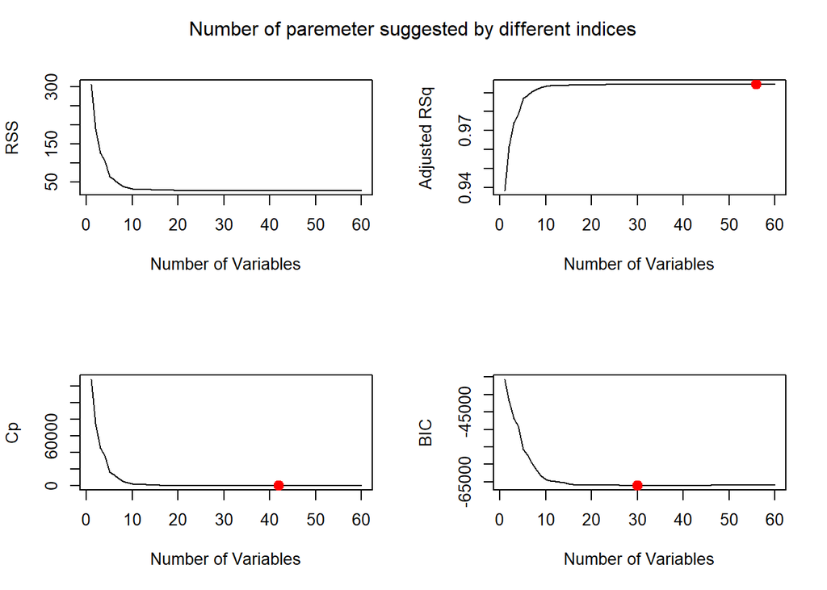

```
##
## Call:
## lm(formula = formula, data = trsf)
##
## Residuals:
##       Min        1Q    Median        3Q       Max
## -0.284622 -0.029005  0.001532  0.029846  0.205652
##
## Coefficients:
##                                      Estimate Std. Error t value Pr(>|t|)
## (Intercept)                         2.183e+00  6.391e-02  34.156  < 2e-16 ***
## age                                -3.343e-02  1.366e-03 -24.469  < 2e-16 ***
## weight_kg                           2.184e-04  7.442e-05   2.935 0.003340 **
## overall                             6.175e-02  1.662e-03  37.160  < 2e-16 ***
## potential                          -2.317e-02  1.360e-03 -17.046  < 2e-16 ***
## international_reputation            3.916e-01  2.568e-02  15.246  < 2e-16 ***
## pace                                3.253e-04  5.203e-05   6.251 4.20e-10 ***
## passing                             8.597e-04  1.855e-04   4.634 3.62e-06 ***
## defending                          -7.550e-04  1.400e-04  -5.394 7.02e-08 ***
## attacking_crossing                 -5.232e-04  7.211e-05  -7.255 4.25e-13 ***
## attacking_finishing                 5.889e-04  5.037e-05  11.692  < 2e-16 ***
## attacking_short_passing             2.134e-04  1.441e-04   1.481 0.138647
## defending_standing_tackle           3.361e-04  1.171e-04   2.869 0.004127 **
## defending_sliding_tackle           -4.923e-04  9.546e-05  -5.157 2.54e-07 ***
## imp_league.TRUE                     4.643e-03  1.108e-03   4.191 2.80e-05 ***
## position.def                       -1.751e-02  1.418e-03 -12.349  < 2e-16 ***
## position.sub                       -3.191e-03  9.235e-04  -3.455 0.000551 ***
## category.bronze                    -7.728e-02  5.669e-03 -13.632  < 2e-16 ***
## category.silver                     9.055e-02  5.850e-03  15.478  < 2e-16 ***
## category.gold                       2.329e-02  6.912e-03   3.370 0.000755 ***
## category.elite                     -1.044e-01  1.494e-02  -6.991 2.86e-12 ***
## phase.prime                        -8.833e-03  2.080e-03  -4.247 2.18e-05 ***
## phase.old                          -2.281e-01  3.389e-03 -67.321  < 2e-16 ***
## phase.near_retirement              -4.316e-01  5.203e-03 -82.950  < 2e-16 ***
## phase.last_year                    -5.326e-01  1.416e-02 -37.610  < 2e-16 ***
## age:overall                        -7.306e-04  4.283e-05 -17.058  < 2e-16 ***
## age:potential                       1.080e-03  4.224e-05  25.567  < 2e-16 ***
## age:international_reputation       -3.811e-03  4.402e-04  -8.656  < 2e-16 ***
## potential:international_reputation -5.253e-03  9.762e-04  -5.381 7.53e-08 ***
## overall:potential                   3.003e-04  1.189e-05  25.247  < 2e-16 ***
## overall:international_reputation    1.752e-03  1.007e-03   1.740 0.081888 .
## ---
## Signif. codes:  0 '***' 0.001 '**' 0.01 '*' 0.05 '.' 0.1 ' ' 1
##
## Residual standard error: 0.04665 on 12776 degrees of freedom
## Multiple R-squared:  0.9944, Adjusted R-squared:  0.9944
## F-statistic: 7.552e+04 on 30 and 12776 DF,  p-value: < 2.2e-16
```

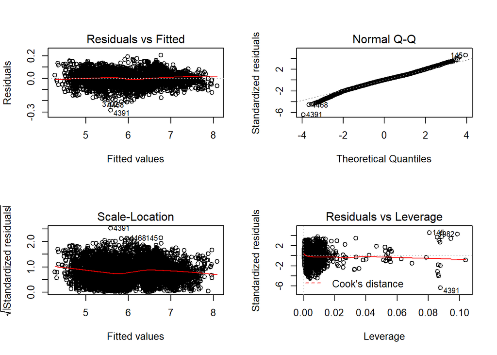

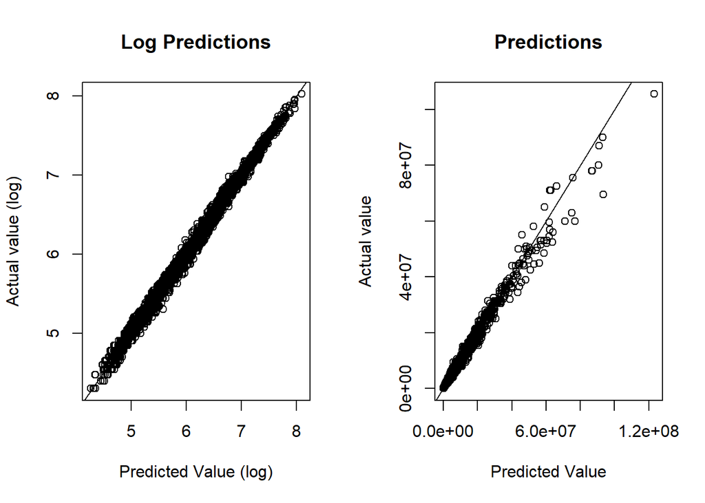

##### Lasso Regression

To perform a LASSO regression, all the interactions added in the model were added to the data frame. Using the *glmnet* library and a cross validation method, the best lambda was chosen and then applied to fit the lasso model. To take into account the different type of variables involved, they were all standardized in the method. This is going to help selecting the most useful variables while all are in the same scale. The coefficient values and the selection done by the model are shown below. A pair of residual plots are shown as well as the prediction one. Also in this case the model seems to perform really well except for some residuals.

```
## 68 x 1 sparse Matrix of class "dgCMatrix"
##                                       s0
## (Intercept)                 1.637136e+00
## age                        -1.495359e-02
## height_cm                   .
## weight_kg                   1.098401e-04
## overall                     5.581864e-02
## potential                   .
## preferred_foot.Right        2.165373e-03
## international_reputation    8.527260e-03
## work_rate.High.Low          .
## work_rate.High.Medium       .
## work_rate.Low.High         -1.098741e-03
## work_rate.Low.Low           .
## work_rate.Low.Medium        .
## work_rate.Medium.High       .
## work_rate.Medium.Low        .
## work_rate.Medium.Medium     .
## pace                        1.546605e-04
## shooting                    .
## passing                     .
## dribbling                   .
## defending                  -1.638452e-04
## physic                      .
## attacking_crossing         -1.933262e-04
## attacking_finishing         6.106913e-04
## attacking_heading_accuracy  .
## attacking_short_passing     4.421143e-04
## attacking_volleys           5.728756e-05
## skill_dribbling             .
## skill_curve                 .
## skill_fk_accuracy           6.054620e-06
## skill_long_passing          .
## skill_ball_control          1.542513e-04
## movement_acceleration       7.544113e-06
## movement_sprint_speed       3.889655e-05
## movement_agility            .
## movement_reactions          3.217083e-05
## movement_balance            .
## power_shot_power            .
```

[output cut: 15 more lines]

```
## position.sub               -3.711895e-04
## category.bronze            -1.116991e-01
## category.silver             6.756002e-02
## category.gold               .
## category.elite             -1.457062e-01
## phase.prime                 2.190132e-02
## phase.old                  -1.954125e-01
## phase.near_retirement      -3.974225e-01
## phase.last_year            -4.758354e-01
## agepotential                .
## ageoverall                  .
## ageintrep                   .
## potentialintrep             .
## overallpotential            2.046343e-04
## overallintrep               .
```

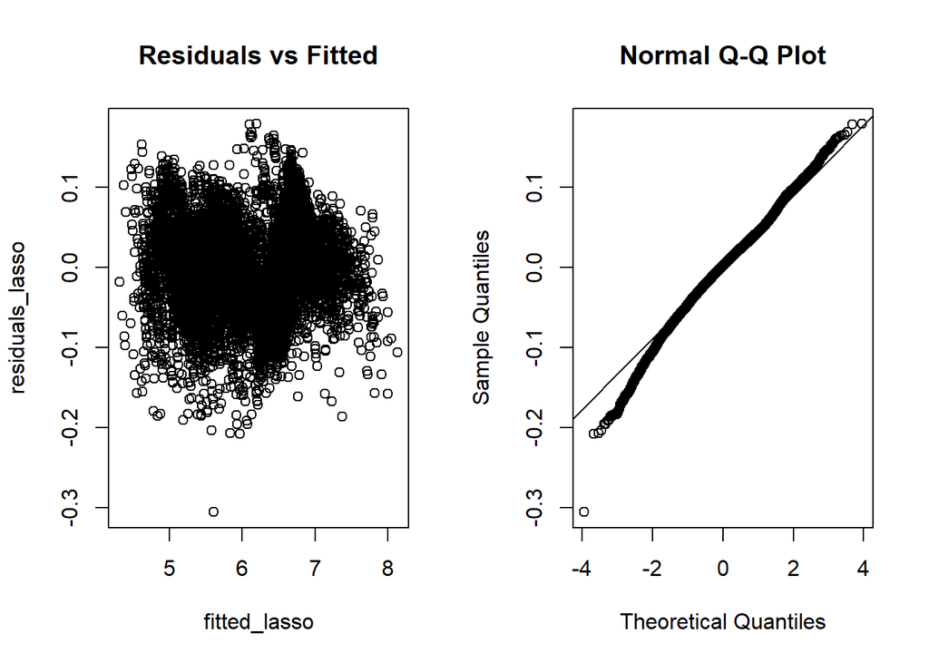

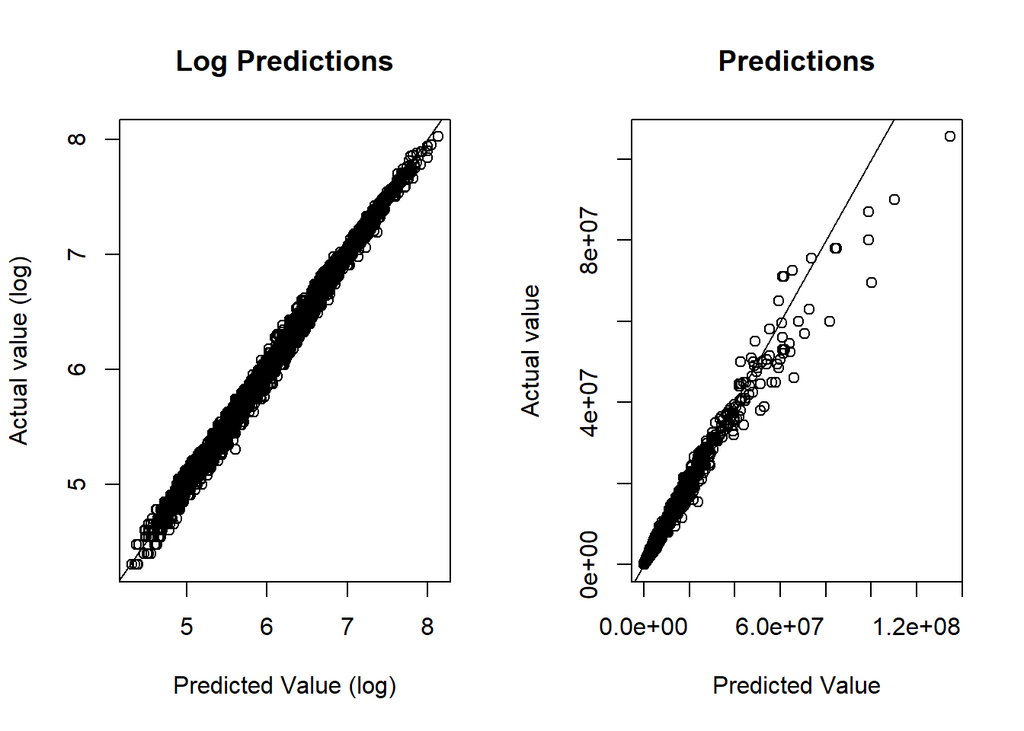

The two models perform in a similar way even if a good number of variables selected are different. It seems that *phase*, *category* and *position* are fundamental for both the models. What we obtain, in general, is that the statistics used in the game are in line with the value of the player and can be used to predict it. Some transformations we did in the preprocessing seem to help a lot, while the forward selection confirms the importance of the four initial guesses for the general sense model. The model we have decided to keep as the best is the forward selected one because it appears simpler to use and has better interpretability. Starting from this model, we are now going to look into the first application, searching for underrated and overrated players.

## Practical Applications

In this section a pair of applications are reported. The first is the main application of the model. The second extends to the usage of other statistics of the dataset in order to try to predict the result of a football match.

##### Underrated and Overrated players

Chosen the model, we are going to use it in our first application. We now assume that our model gives the correct value of each player, and by this we watch for the 20 more distant observations from it. We are going to see which players are the most underrated and overrated for the model. In particular, we report two types of ranking, the first based on the ratio between prediction and real value, the second based on the greatest positive/negative residuals. The two rankings are reported using the original scale of the *value* variable. The main distinction between the two rankings is that the ratio-based seems more fair, since it’s acting through the whole data frame, while the residual-based focuses on the players which already have a large value and get a high residual from the model (both positive or negative).  
This application is pretty general and needs a validation from some experts in order to see if the reported results have a real world sense. There may be some variables not available - like the tendency to be injured - that could change the way we have to interpret the results given by the model. On the other hand, it can be simple, fast and useful as a basis from which to start. Working with data, it is also possible to select different age groups or statistics ranges in order to select those categories of players in which you are more interested. For example, a similar kind of application has already been successfully tested in the past in the baseball context as described in the movie - based on a true story - Moneyball (https://en.wikipedia.org/wiki/Moneyball_(film)).

```
## [1] "Undervalued:"
```

```
##                 names   value predicted_value    ratio
## 4391         L. Licht  200000        385169.4 1.925847
## 4468        Serey Dié  575000        938512.6 1.632196
## 3702      A. Eschenko  425000        684934.6 1.611611
## 3715    H. Medunjanin  750000       1202777.8 1.603704
## 4505     D. Novaretti  550000        867268.3 1.576851
## 8139        B. Safari  180000        282139.3 1.567440
## 3684        K. Vadócz  750000       1165675.1 1.554233
## 5267     M. Silvestre  325000        502653.0 1.546624
## 3244    M. Piedrahita  875000       1351060.0 1.544069
## 4594    S. Gentiletti  550000        848586.1 1.542884
## 6140  A. Papadopoulos  275000        423113.3 1.538594
## 4385     O. Deschacht  240000        362018.9 1.508412
## 6139          E. Ruud  160000        241182.6 1.507391
## 5531      J. Céspedes  190000        285960.4 1.505055
## 7133       M. Gazzola  220000        329470.4 1.497593
## 11393         E. Goñi  100000        149089.3 1.490893
## 522         M. Parolo 4000000       5956533.1 1.489133
## 7108     J. Bornstein  220000        326520.2 1.484183
## 8433      S. Yamamoto  180000        265898.1 1.477212
## 3699       Y. Cahuzac  750000       1101480.4 1.468641
```

```
##                  names     value predicted_value  residual
## 22           J. Sancho  69500000        93297888 -23797888
## 6            K. Mbappé 105500000       123080521 -17580521
## 23 T. Alexander-Arnold  60000000        76827753 -16827753
## 24     Bruno Fernandes  63000000        74923873 -11923873
## 37              H. Son  52500000        63643004 -11143004
## 33       P. Aubameyang  45000000        56042785 -11042785
## 28      Bernardo Silva  60000000        70954050 -10954050
## 85          E. Haaland  45000000        55931481 -10931481
## 3       R. Lewandowski  80000000        90698931 -10698931
## 35         C. Immobile  48500000        58836005 -10336005
## 32         A. Di María  39000000        48228698  -9228698
## 42            A. Gómez  34500000        43585188  -9085188
## 8              S. Mané  78000000        86977556  -8977556
## 9             M. Salah  78000000        86554325  -8554325
## 86         L. Martínez  44500000        53019857  -8519857
## 87           Oyarzabal  42500000        50990356  -8490356
## 38     Roberto Firmino  52000000        60212748  -8212748
## 46        J. Henderson  36500000        44526000  -8026000
## 25          A. Laporte  56000000        63969054  -7969054
## 34     Sergio Busquets  38000000        45636210  -7636210
```

```
## [1] "Overvalued:"
```

```
##                names   value predicted_value     ratio
## 145   Z. Ibrahimovic 9500000      5916585.04 0.6227984
## 1982    M. Rodríguez 1500000       964772.82 0.6431819
## 1554      R. Palacio 2400000      1604586.74 0.6685778
## 1553         J. Sand 1900000      1284658.30 0.6761359
## 2530      E. Paredes 1200000       818250.21 0.6818752
## 1995    S. Sessègnon 1900000      1314191.00 0.6916795
## 269        F. Ribéry 6500000      4510462.42 0.6939173
## 1989       G. Hoarau 2000000      1391281.37 0.6956407
## 1988    D. Cvitanich 2000000      1392042.03 0.6960210
## 16643    F. Cárdenas   60000        41980.29 0.6996716
## 1985        A. Turan 3400000      2380967.13 0.7002845
## 1986    K. Huntelaar 2000000      1402502.43 0.7012512
## 10299  S. Maierhofer  160000       112296.15 0.7018509
## 12928      D. Matsui   70000        49238.53 0.7034076
## 13660  Ryang Yong Gi   70000        49488.39 0.7069771
## 16642      M. Flores   60000        42523.00 0.7087167
## 1552        M. Noble 3900000      2767477.32 0.7096096
## 1712      P. Capelle 4000000      2839141.87 0.7097855
## 2001         S. Long 3500000      2487067.95 0.7105908
## 1998         I. Sosa 3400000      2429738.75 0.7146290
```

```
##               names    value predicted_value residual
## 18         T. Kroos 55000000        45932383  9067617
## 16          H. Kane 71000000        62270957  8729043
## 17        P. Dybala 71000000        62804704  8195296
## 14      R. Sterling 72500000        66264790  6235210
## 20     K. Koulibaly 50000000        43777149  6222851
## 15       J. Kimmich 65000000        59040909  5959091
## 30        L. Suárez 31500000        25929741  5570259
## 19        E. Hazard 58000000        52699638  5300362
## 196          E. Can 26500000        22587204  3912796
## 56       Marquinhos 44000000        40114067  3885933
## 50         J. Vardy 28000000        24376345  3623655
## 157        A. Vidal 15000000        11388960  3611040
## 145  Z. Ibrahimovic  9500000         5916585  3583415
## 70       D. Mertens 24000000        20654687  3345313
## 98       S. de Vrij 30500000        27362850  3137150
## 141      K. Manolas 24500000        21397448  3102552
## 111       J. Corona 32500000        29401317  3098683
## 1301        T. Kubo 14500000        11739599  2760401
## 146   João Moutinho 15000000        12345061  2654939
## 201        D. Djené 21500000        18845985  2654015
```

##### Match modeling using Elos and overall strength of a team

In this application we are interested in creating a model that is able to predict the general result of a football match by the side of the home team: win, draw or lose. This is done by using three models that predicts the probability of winning, drawing or losing. The highest probability obtained is used to predict the result of that match. We are going to use a very simple model and see how it performs on the same data it was trained on. At the end, we are going to compare the probability we are estimating with the intrinsic one given by the real odds used by bookmakers.  
For this application, the dataset was taken from https://www.football-data.co.uk/italym.php. We use also some data taken from http://clubelo.com/. The first dataset contains match results while in the *clubelo* site, the Elo ratings were taken. As the site reports: “A club’s Elo rating is an estimation of its strength based on past results allowing predictions for the future”. We are going to use Elo ratings to dynamically change the estimated strenght of a team. A small (inactive) preprocessing is reported, in which the result is encoded, given the goals on both parts. Furthermore the Elo values are calculated and correctly assigned to all the teams during all the season. Two new tables are then saved and loaded for the starting of the analysis.

For the models estimation, three new variables are created as vectors taking value 1 when the home team wins/draws/loses, and 0 otherwise. Only the 16 most important players of every team are selected by omitting the team position *“SUB”*. For taking into account the strength of a team, the *overall* statistic is summed up for all the players in that team. This value is then rescaled for all the matches of the season by a weight calculated using the elo. This weight is equal to the percentage of change of elo rating with respect to beginning. The *overall_strength* of each team thus calculated is then put in the right position into the matrix of the matches. An additive factor of 4.5 is added to home_overall_strenght to take into account the home advantage.

To calculate the models, the difference between the *overall_strengths* of the two teams is calculated. This is used in the models to fit respectively the wins, draws and losses. In order to have probabilities as outputs, the models used were generalized linear models of binomial family with logit link function. The summary of the models are reported. The model used to predict the draw outcome has a non-significant covariate. This result is coherent with what has been also seen in the litterature. One interesting thing of these models is that the weights calculated in the win and loss models are very similar in value and of opposite sign. This means that the relationship home versus away is understood by the models.

```
## [1] "Home wins model: "
```

```
##
## Call:
## glm(formula = home_win ~ overall_diff, family = "binomial", data = match)
##
## Deviance Residuals:
##     Min       1Q   Median       3Q      Max
## -1.8357  -0.9169  -0.4983   0.9398   2.2334
##
## Coefficients:
##                Estimate Std. Error z value Pr(>|z|)
## (Intercept)  -0.4711696  0.1196655  -3.937 8.24e-05 ***
## overall_diff  0.0067056  0.0008286   8.093 5.82e-16 ***
## ---
## Signif. codes:  0 '***' 0.001 '**' 0.01 '*' 0.05 '.' 0.1 ' ' 1
##
## (Dispersion parameter for binomial family taken to be 1)
##
##     Null deviance: 513.82  on 379  degrees of freedom
## Residual deviance: 426.33  on 378  degrees of freedom
## AIC: 430.33
##
## Number of Fisher Scoring iterations: 4
```

```
## [1] "Draw model: "
```

```
##
## Call:
## glm(formula = draw ~ overall_diff, family = "binomial", data = match)
##
## Deviance Residuals:
##     Min       1Q   Median       3Q      Max
## -0.8715  -0.7817  -0.7484   1.5473   1.7396
##
## Coefficients:
##                Estimate Std. Error z value Pr(>|z|)
## (Intercept)  -1.0743555  0.1180132  -9.104   <2e-16 ***
## overall_diff -0.0006813  0.0006973  -0.977    0.329
## ---
## Signif. codes:  0 '***' 0.001 '**' 0.01 '*' 0.05 '.' 0.1 ' ' 1
##
## (Dispersion parameter for binomial family taken to be 1)
##
##     Null deviance: 431.71  on 379  degrees of freedom
## Residual deviance: 430.76  on 378  degrees of freedom
## AIC: 434.76
##
## Number of Fisher Scoring iterations: 4
```

```
## [1] "Home lose model: "
```

```
##
## Call:
## glm(formula = away_win ~ overall_diff, family = "binomial", data = match)
##
## Deviance Residuals:
##     Min       1Q   Median       3Q      Max
## -1.8442  -0.8479  -0.4975   0.9471   2.3620
##
## Coefficients:
##                Estimate Std. Error z value Pr(>|z|)
## (Intercept)  -0.8517227  0.1272184  -6.695 2.16e-11 ***
## overall_diff -0.0064427  0.0008411  -7.660 1.86e-14 ***
## ---
## Signif. codes:  0 '***' 0.001 '**' 0.01 '*' 0.05 '.' 0.1 ' ' 1
##
## (Dispersion parameter for binomial family taken to be 1)
##
##     Null deviance: 485.58  on 379  degrees of freedom
## Residual deviance: 409.04  on 378  degrees of freedom
## AIC: 413.04
##
## Number of Fisher Scoring iterations: 4
```

The probabilities calculated are used to see how much the model is able to predict the same data. The accuracy obtained is over 50% and is better than predicting always the same result. In the final plot the probabilities provided by the bookmaker B365 of home winning, calculated as odds, are compared with our home winning probabilities. There’s a clear relationship between the results of our model and the results of the bookmaker, meaning that our model provides probabilities similar to the ones calculated with more complex models.

```
## Accuracy of the predictions:  0.5552632
```

```
## Accuracy of predicting only home wins:  0.4078947
```

```
## Accuracy of predicting only home draws:  0.2552632
```

```
## Accuracy of predicting only home loses:  0.3368421
```

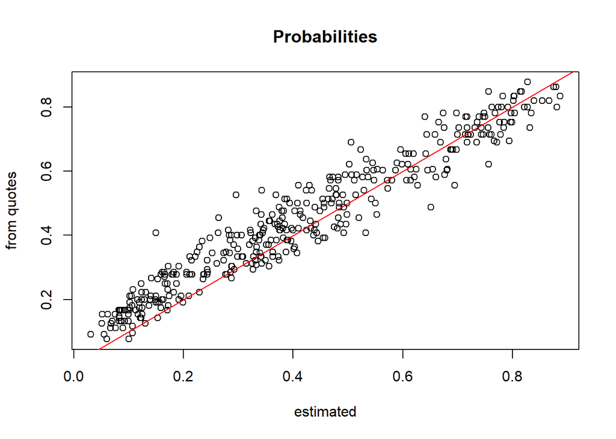

## Conclusions

In this project we wanted to establish if there was a relationship between the football data provided by FIFA 21 with the real world, to do so we tried to predict the market value of active professional players. We have also provided two useful applications that are dealt very frequently in statistical analysis in the soccer field. There are numerous works in this area because soccer is a difficult sport to model because it contains a lot of randomness.

The realization of this project has been an interesting journey into statistical analysis. From it we have learned how important it is to be able to analyze the variables at the start in order to get a good model. In particular, data preprocessing was the step that took most of the time and effort. In particular, we saw that sometimes transforming and grouping can really help in getting a simpler and more effective model. It has been interesting to see that sometimes a general sense model, using intuitive variables, is not that bad and that by model selection and regularization we can obtain different models but with similar explicative power.

## References

*Data taken at:*  
https://www.kaggle.com/stefanoleone992/fifa-21-complete-player-dataset  
https://www.football-data.co.uk/italym.php  
http://clubelo.com/

*Github:*  
https://github.com/SunPy-FIS/Statistical-learning-2021

*Cited:*  
https://www.transfermarkt.it/uefa-champions-league/marktwerte/pokalwettbewerb/CL  
https://en.wikipedia.org/wiki/Moneyball_(film)

*Others:*  
https://www.statista.com/statistics/1087391/global-sports-market-size/  
Behravan, Iman and Razavi, Seyed Mohammad (2021). *A novel machine learning method for estimating football players’ value in the transfer market*. Soft Computing. 25(3), 2499-2511.  
Cotta, Leonardo and de Melo, POV and Benevenuto, Fabricio and Loureiro (2010). *Using fifa soccer video game data for soccer analytics*. International Journal of forecasting. 26(3), 460-470.  
Hvattum, Lars Magnus and Arntzen, Halvard (2016). *Using ELO ratings for match result prediction in association football*. Workshop on large scale sports analytics.  
Dixon, Mark J and Coles, Stuart G (1997). *Modelling association football scores and inefficiencies in the football betting market*. Journal of the Royal Statistical Society: Series C (Applied Statistics). 46(2), 265-280.

*n.b. References are valid for the whole project: report and presentation. All rights reserved.*

[figure not shown]